# boxplot_excise

## 도전과제.

- df 자료를 불러와 아래의 그림을 그리세요.

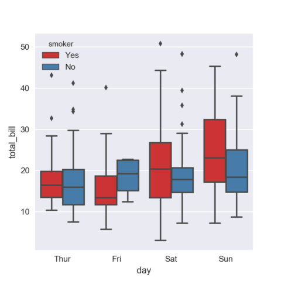

- 요일의 순서를 Thur, Fri, Sat, Sun 로 맞출 필요는 없습니다.
- 아래의 코드를 참고하여 그리세요.

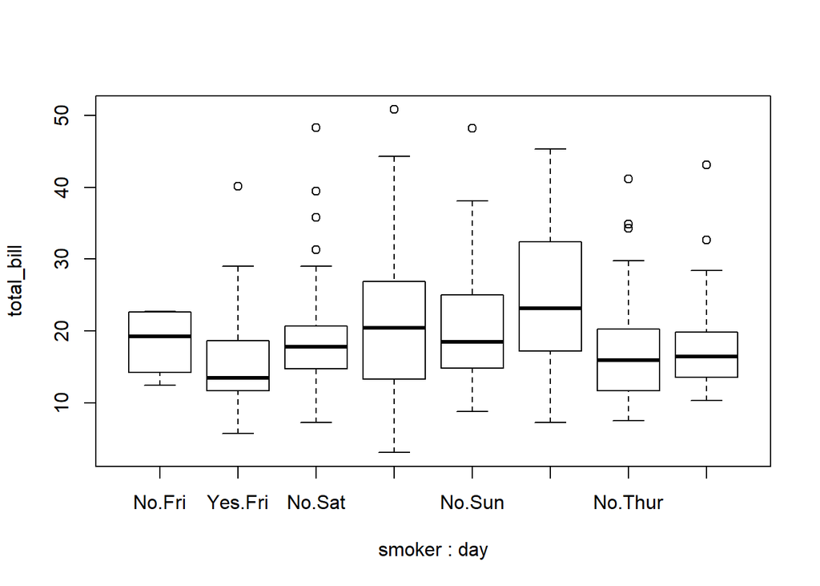

```r
df <- read.csv("https://raw.githubusercontent.com/plotly/datasets/master/violin_data.csv")
boxplot(total_bill~smoker+day, data=df)
```

## 과제 2. 바이올린 그림 그리기

- 과제 1의 df 자료를 사용하여 아래의 그림을 그리세요.

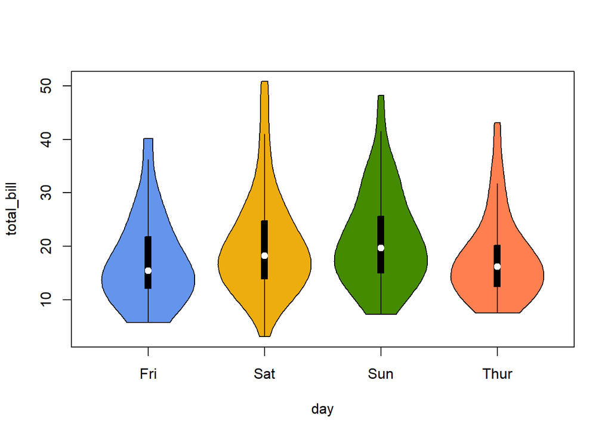

## 과제 3. 상자그림과 jitter그림

- ChickWeight 자료를 사용하여 아래의 그림을 그리세요.

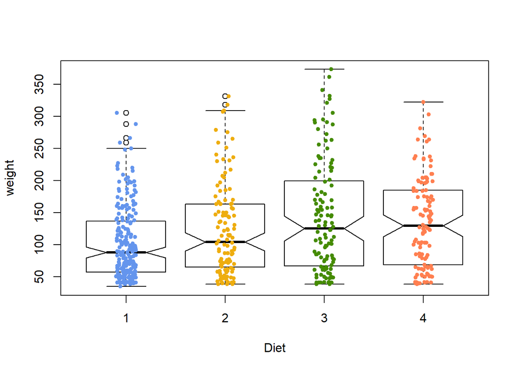

## 과제 4. mpg 자료를 사용하여 아래 그림을 그리세요.

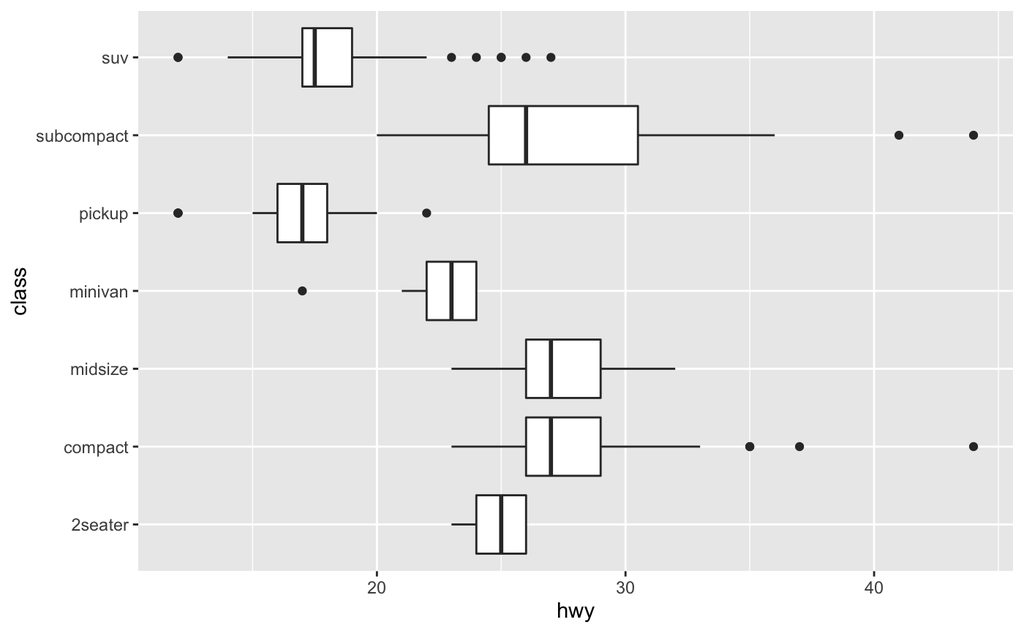

- 똑같이 그릴 필요는 없습니다.
- 즉, 아래와 같이 그려도 됩니다. :)

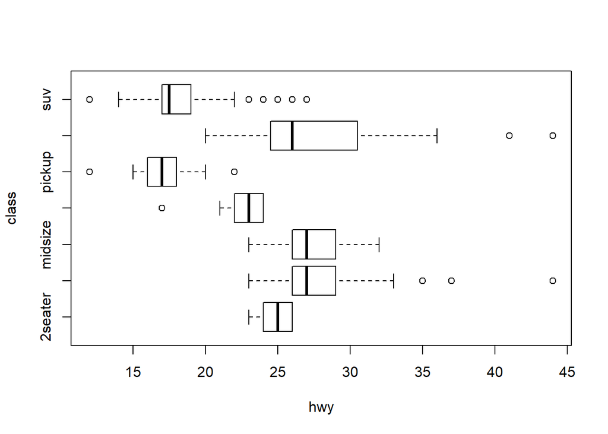